# Human traits Fst

Ian Brettell

5 January 2021

# 1. Setup

- Working directory on EBI Cluster: `/hps/research1/birney/users/ian/hmn_fst`
- GitHub repository: https://github.com/brettellebi/human_traits_fst

## `conda` env on cluster

```r
# Create env on cluster with mamba
mamba create -y \
  -n fst_env_rhel \
  -c bioconda gatk4
conda activate fst_env_rhel
mamba install bcftools plink2 r-base r-essentials r-tidyverse r-units libgdal r-sf
# Export
conda env export \
  --no-builds \
  -f envs/fst_env_rhel.yml
# Activate
conda activate fst_env_rhel
```

## 1.1. `renv`

```r
# Export env (to renv.lock file)
renv::init()
# To install packages on new system, or 'activate' the env:
renv::restore()
```

Load libaries

```r
library(tidyverse)
library(pegas)
library(knitr)
```

## 1.3. Download 1GK data

### 1.3.1. Download from FTP

```r
wget \
  -r -p -k \
  --no-parent \
  -cut-dirs=5 \
  ftp://ftp.1000genomes.ebi.ac.uk/vol1/ftp/release/20130502/
```

### 1.3.2. Put list of files into list

```r
find vcfs/ftp.1000genomes.ebi.ac.uk/ALL.chr*.vcf.gz \
  > human_traits_fst/data/20200205_vcfs.list
```

### 1.3.3. Merge VCFs

```r
java -jar /nfs/software/birney/picard-2.9.0/picard.jar MergeVcfs \
  I=human_traits_fst/data/20200205_vcfs.list \
  O=vcfs/1gk_all.vcf.gz
# Exception in thread "main" java.lang.IllegalArgumentException: The contig entries in input file /hps/research1/birney/users/ian/rac_hyp/vcfs/ftp.1000genomes.ebi.ac.uk/ALL.chrMT.phase3_callmom-v0_4.20130502.genotypes.vcf.gz are not compatible with the others.

# So remove that one from list above
sed -i '/MT/d' human_traits_fst/data/20200205_vcfs.list

# run MergeVCFs again
java -jar /nfs/software/birney/picard-2.9.0/picard.jar MergeVcfs \
  I=human_traits_fst/data/20200205_vcfs.list \
  O=vcfs/1gk_all.vcf.gz

# Exception in thread "main" java.lang.IllegalArgumentException: The contig entries in input file /hps/research1/birney/users/ian/rac_hyp/vcfs/ftp.1000genomes.ebi.ac.uk/ALL.chrY.phase3_integrated_v2a.20130502.genotypes.vcf.gz are not compatible with the others.
sed -i '/chrY/d' human_traits_fst/data/20200205_vcfs.list

# run MergeVCFs again
java -jar /nfs/software/birney/picard-2.9.0/picard.jar MergeVcfs \
  I=human_traits_fst/data/20200205_vcfs.list \
  O=vcfs/1gk_all.vcf.gz
# SUCCESS
```

## 1.4. Obtain GWAS data

### 1.4.1. Educational attainment

Data download link: https://static-content.springer.com/esm/art%3A10.1038%2Fs41588-018-0147-3/MediaObjects/41588_2018_147_MOESM3_ESM.xlsx

Saved here: `data/20180723_Lee-et-al_supp-tables.xlsx`

Notes: - European-ancestry cohort only. - *n* = 1,131,881 individuals. - SNP panel: ~10M from 1GKph3. - Phenotype: number of years of schooling that individuals completed (EduYears). - Identified **1271** independent SNPs at the genome-wide significance level of 5e-8 (or **995** at *P* < 1e-8). - COJO: reduced to **765** at *P* < 5e-8: https://doi.org/10.1038/ng.2213 - Corrected by LD score regression: only ~5% of inflation attributable to bias. LD score intercept of 1.11.

### 1.4.2. Height

From **Yengo et al. (2018)** Meta-analysis of genome-wide association studies for height and body mass index in approximately 700000 individuals of European ancestry, *Human Molecular Genetics*: https://academic.oup.com/hmg/article-abstract/27/20/3641/5067845.

Notes: - European-ancestry cohort only. - Meta-analysis combining GIANT and UKBioBank cohorts from Wood et al. (2014) https://doi.org/10.1038/ng.3097 (height) and Locke et al. (2015) https://doi.org/10.1038/nature14177 (BMI). - *n* = Up to 795,624 individuals (456426 from UKBioBank and the rest (339198?) from GIANT). - SNP panel: ~2.4M HM2 SNPs. - Identified **3290** (2388 main, 902 secondary; 712 loci) and **941** (656 main, 285 secondary; 536 loci) near-independent SNPs associated with height and BMI respectively, at a genome-wide significance threshold of *P* < 1e−8). - Analysed with COJO: https://doi.org/10.1038/ng.2213 - Corrected by LD score regression: LD score intercept of 1.48 and 1.03 for height and BMI respectively.

Data downloaded from this webpage: https://portals.broadinstitute.org/collaboration/giant/index.php/GIANT_consortium_data_files Data download link: https://portals.broadinstitute.org/collaboration/giant/images/4/4b/Meta-analysis_Wood_et_al%2BUKBiobank_2018_top_3290_from_COJO_analysis.txt.gz

```r
cd human_traits_fst/data
# download
wget https://portals.broadinstitute.org/collaboration/giant/images/4/4b/Meta-analysis_Wood_et_al%2BUKBiobank_2018_top_3290_from_COJO_analysis.txt.gz
# unzip
gunzip Meta-analysis_Wood_et_al%2BUKBiobank_2018_top_3290_from_COJO_analysis.txt.gz
# rename
mv Meta-analysis_Wood_et_al+UKBiobank_2018_top_3290_from_COJO_analysis.txt 20181015_Yengo-et-al_snps_height.txt
```

Saved here: `data/20181015_Yengo-et-al_snps_height.txt`

### BMI

From **Yengo et al. (2018)** Meta-analysis of genome-wide association studies for height and body mass index in approximately 700000 individuals of European ancestry, *Human Molecular Genetics*: https://academic.oup.com/hmg/article-abstract/27/20/3641/5067845. (Same study as above.)

Data download link: https://portals.broadinstitute.org/collaboration/giant/images/e/e2/Meta-analysis_Locke_et_al%2BUKBiobank_2018_top_941_from_COJO_analysis_UPDATED.txt.gz

```r
# download
wget -P data https://portals.broadinstitute.org/collaboration/giant/images/e/e2/Meta-analysis_Locke_et_al%2BUKBiobank_2018_top_941_from_COJO_analysis_UPDATED.txt.gz
# unzip
gunzip data/Meta-analysis_Locke_et_al+UKBiobank_2018_top_941_from_COJO_analysis_UPDATED.txt.gz
# rename
mv data/Meta-analysis_Locke_et_al+UKBiobank_2018_top_941_from_COJO_analysis_UPDATED.txt data/20181015_Yengo-et-al_snps_bmi.txt
```

### 1.4.3. IBD

#### Huang et al. (2017)

From **Huang et al. (2017)** Fine-mapping inflammatory bowel disease loci to single-variant resolution, *Nature*: https://www.nature.com/articles/nature22969#Sec29.

Notes: - European-ancestry cohort - *n* = 67,852 individuals - Identified **94** loci - Take from `list of credible sets` those with “1” in `signal` column.

Data download link (Supplementary Table 1): https://static-content.springer.com/esm/art%3A10.1038%2Fnature22969/MediaObjects/41586_2017_BFnature22969_MOESM2_ESM.xlsx

Saved here: `data/20170628_Huang-et-al_supp-table-1.xlsx`

#### Jostins et al. (2012)

From **Jostins et al. (2012)** Host–microbe interactions have shaped the genetic architecture of inflammatory bowel disease, *Nature*: https://www.nature.com/articles/nature11582

Notes: - European-ancestry cohort - *n* = 41,660 individuals - SNP panel: 1.23M imputed SNPs from HM3 - Identified 193 independent SNPs associated with at least one of Crohn’s, UC, or IBD, at genome-wide significance of *P* < 5e-8, merged into **163** loci.

Data download link (Supplementary Table 2): https://static-content.springer.com/esm/art%3A10.1038%2Fnature11582/MediaObjects/41586_2012_BFnature11582_MOESM90_ESM.zip

Saved here: `data/20121031_Jostins-et-al_supp-table-2.xlsx`

### 1.4.4. Skin pigmentation

[**NOTE**: All other traits have SNP-hits based on only European-ancestry populations. Here, the SNP hits come from various populations. Potential bias? Or if we only had pigmentation SNP-hits from European populations, would we expect the Fst to be even more skewed?]{colour = “red”}

- **Crawford et al. (2017)** Loci associated with skin pigmentation identified in African populations, *Science*: https://doi.org/10.1126/science.aan8433. Take table 1, and manually transform ‘Ancestral>Divided’ column into new columns titled ‘tested_allele’ (the allele in bold) and ‘other_allele’. Save here: `data/20171117_Crawford-et-al_Table-1.xlsx`
- **Adhikari et al. (2019)** A GWAS in Latin Americans highlights the convergent evolution of lighter skin pigmentation in Eurasia, *Nature*: https://doi.org/10.1038/s41467-018-08147-0. “Summary statistics from the GWAS analyses is deposited at GWAS central with the link http://www.gwascentral.org/study/HGVST3308”. Under the ‘Association results’ tab, there is one dataset for each of the 6 phenotypes tested:
  - Melanin index
  - Hair color
  - Eye color
  - Digital eye color: L (lightness)
  - Digital eye color: C (chroma)
  - Digital eye color: cosH (cosine of hue) Difficult to ascertain which ones had genome-wide significance. Instead, pull tables directly from paper and supplementary materials, and put here in different sheets: `data/20190121_Adhikari-et-al_snps.xlsx`
  - *Table 1*: 18 lead SNPs from paper, each with a different p-value for one of the 6 phenotypes.
  - *supp_table_6*: 11 SNPs associated with combined traits.
  - *supp_table_12*: 161 SNPs collagted from published association studies on pigmentation. See table for references, which were used to identify other pigmentation GWAS studies.
- **Hernandez-Pacheco et al. (2017)** Identification of a novel locus associated with skin colour in African-admixed populations, *Scientific Reports*: https://doi.org/10.1038/srep44548. 9 hits with genome-wide significance here: `data/20170316_Hernandez-Pacheco-et-al.xlsx`.

Others compiled into the single XLSX doc `data/20200622_pigmentation_snps.xlsx`:

- 20190321_Jonnalagadda-et-al: **Jonnalagadda et al. (2019)** A Genome-Wide Association Study of Skin and Iris Pigmentation among Individuals of South Asian Ancestry, *Genome Biology and Evolution*: https://academic.oup.com/gbe/article/11/4/1066/5416147. Took 9 SNPs associated with iris colour from Table 1, and 14 SNPs described in previous studies from Table 2.
- 20171130_Martin-et-al: **Martin et al. (2017)** An Unexpectedly Complex Architecture for Skin Pigmentation in Africans, *Cell*: https://www.cell.com/cell/fulltext/S0092-8674%2817%2931324-7. Took all 42 SNPs from Table S6A in Supplemental Information here: https://www.cell.com/cms/10.1016/j.cell.2017.11.015/attachment/eccead83-1a96-4444-9032-f968ee481d15/mmc2.xlsx.
- 20150512_Liu-et-al: **Liu et al. (2015)** Genetics of skin color variation in Europeans: genome-wide association studies with functional follow-up, *Human Genetics*: https://link.springer.com/article/10.1007%2Fs00439-015-1559-0. Took all 9 SNPs from Table 1.
- 20121031_Candille-et-al: **Candille et al. (2012)** Genome-wide association studies of quantitatively measured skin, hair, and eye pigmentation in four European populations, *PLoS One*: https://journals.plos.org/plosone/article?id=10.1371/journal.pone.0048294. Took all 8 SNPs from Table 2.
- 20100614_Gerstenblith-et-al: **Gerstenblith et al. (2010)** Genome-wide association studies of pigmentation and skin cancer: a review and meta-analysis, *Pigment Cell Melanoma Research*: https://onlinelibrary.wiley.com/doi/full/10.1111/j.1755-148X.2010.00730.x. Took all 39 SNPs from Table 4.
- 20080516_Han-et-al: **Han et al. (2008)** A Genome-Wide Association Study Identifies Novel Alleles Associated with Hair Color and Skin Pigmentation, *PLOS Genetics*: https://journals.plos.org/plosgenetics/article?id=10.1371/journal.pgen.1000074. Took all 38 SNPs from Table 2.

#### Create list of target SNPs

```r
pig_snps <- list()
# Crawford
pig_snps[["crawford"]] <- readxl::read_excel(here("data", "20171117_Crawford-et-al_Table-1.xlsx")) %>%
  dplyr::select(rsid = "RSID", everything()) %>%
  dplyr::filter(!is.na(rsid),
                !rsid == ".")
```

[output not shown]

## 1.5. Filter 1GK VCF for target SNPs

### Create lists of target SNPs

#### EDU

```r
## extract from excel doc
snps_eduyrs <- readxl::read_xlsx(here::here("data", "20180723_Lee-et-al_supp-tables.xlsx"), sheet = "2. EduYears Lead SNPs", skip = 1, n_max = 1271)
## write table of SNPs
write.table(snps_eduyrs[["SNP"]], here::here("data", "snps_edu.list"), quote = F, row.names = F, col.names = F)
```

#### HEI

```r
cut -f1 human_traits_fst/data/20181015_Yengo-et-al_snps_height.txt | tail -n+2 \
  > human_traits_fst/data/snps_hei.list
```

#### BMI

```r
cut -f1 human_traits_fst/data/20181015_Yengo-et-al_snps_bmi.txt | tail -n+2 \
  > human_traits_fst/data/snps_bmi.list
```

#### IBD

```r
# extract from excel doc
snps_ibd <- readxl::read_xlsx(path = here::here("data", "20170628_Huang-et-al_supp-table-1.xlsx"),
                      sheet = "list of credible sets") %>%
  dplyr::filter(signal == 1) %>% # take first-ranked SNP in locus
  dplyr::filter(!grepl("chr", variant.lead)) %>% # remove SNPs without rsID
  dplyr::select(variant.lead) # take just rsID

# write tables of SNPs
write.table(x = snps_ibd$variant.lead,
            file = here::here("data", "snps_ibd.list"),
            quote = F,
            row.names = F,
            col.names = F)
```

#### PIG

```r
write.table(x = pig_df$rsid,
            file = here::here("data", "snps_pig.list"),
            quote = F,
            row.names = F,
            col.names = F)
```

### Create filtered VCFs

```r
traits=$(echo edu hei bmi ibd pig)

for trait in $(echo $traits ); do
  gatk SelectVariants \
    -R refs/hs37d5.fa.gz \
    -V vcfs/1gk_all.vcf.gz \
    --keep-ids human_traits_fst/data/snps_$trait.list \
    -O vcfs/snphits_$trait.vcf.gz ;
done
```

## 1.6. Get allele frequencies with `Plink2`

### 1.6.1. Import 1GK metadata (for sample-population key)

Downloded via this page: http://www.internationalgenome.org/data Download link: http://ftp.1000genomes.ebi.ac.uk/vol1/ftp/technical/working/20130606_sample_info/20130606_sample_info.xlsx.

Saved here: `data/20130606_sample_info.xlsx`

### 1.6.2. Write population file for Plink2

```r
write.table(meta[, 1:2],
            here::here("data", "plink2_sample_popn_key.txt"),
            quote = F,
            sep = "\t",
            row.names = F,
            col.names = F)
```

### 1.6.3. Set up directories on EBI cluster

```r
mkdir -p human_traits_fst/data/20200622_plink2_alfreqs

traits=$(echo edu hei ibd pig)

for i in $(echo $traits); do
  mkdir -p human_traits_fst/data/20200622_plink2_alfreqs/$i;
done
```

### 1.6.4. Run `Plink2`

```r
traits=$(echo edu hei bmi ibd pig)

# Get AF per population
for trait in $(echo $traits); do
  # make directory
  mkdir -p human_traits_fst/data/20200622_plink2_alfreqs/$trait ;
  # create allele-freq tables
  plink2 \
    --vcf vcfs/snphits_$trait.vcf.gz \
    --freq \
    --max-alleles 2 \
    --pheno iid-only human_traits_fst/data/plink2_sample_popn_key.txt \
    --loop-cats PHENO1 \
    --out human_traits_fst/data/20200622_plink2_alfreqs/$trait/$trait ;
done

# Get global AF
for trait in $(echo $traits); do
  # make directory
  mkdir -p human_traits_fst/data/20200622_plink2_alfreqs/$trait ;
  # create allele-freq tables
  bsub \
    -o log/alfreq_global_$trait.out \
    -e log/alfreq_global_$trait.err \
    """
    conda activate fst_env_rhel ;
    plink2 \
      --vcf vcfs/snphits_$trait.vcf.gz \
      --freq \
      --max-alleles 2 \
      --out human_traits_fst/data/20200622_plink2_alfreqs/$trait/$trait.all
    """;
done
```

# 2. Analysis

## Set plotting parameters

```r
# Create vector for recoding traits with full names
recode_vec = c("edu" = "Educational attainment",
               "hei" = "Height",
               "bmi" = "BMI",
               "ibd" = "IBD",
               "pig" = "Pigmentation")
# Colour palette
fill_pal = c("Educational attainment" = "#00afbb",
             "Height" = "#FFBF00",
             "BMI" = "#0bc166",
             "IBD" = "#360568",
             "Pigmentation" = "#fc4e07")
```

## 2.1. Compare allele frequencies

### Histograms of the global MAF distributions (i.e. in all populations together)

```r
# Get list of files
target_files = list.files(here::here("data", "20200622_plink2_alfreqs"),
                          pattern = "all.afreq",
                          recursive = T,
                          full.names = T)

# Read in data
alfreq_list_glob = lapply(target_files, function(file){
  trait_df = read.table(file,
                        header = T,
                        comment.char = "")

})

# Set names
names(alfreq_list_glob) = gsub(pattern = ".all.afreq",
                       replacement = "",
                       basename(target_files))

# Merge into single Df
alfreq_glob_df = dplyr::bind_rows(alfreq_list_glob, .id = "trait")

# Get major and minor alleles and frequency
alfreq_glob_df = alfreq_glob_df %>%
  dplyr::mutate(MAJ = if_else(ALT_FREQS <= 0.5,
                              REF,
                              ALT),
                MIN = ifelse(ALT_FREQS <= 0.5,
                             ALT,
                             REF),
                MAF = ifelse(ALT_FREQS <= 0.5,
                             ALT_FREQS,
                             1 - ALT_FREQS))

# Make `trait` a factor
alfreq_glob_df$trait = factor(alfreq_glob_df$trait, levels = trait_levels)
# Recode traits for plotting
alfreq_glob_df$trait = dplyr::recode(alfreq_glob_df$trait, !!!recode_vec)
```

Plot

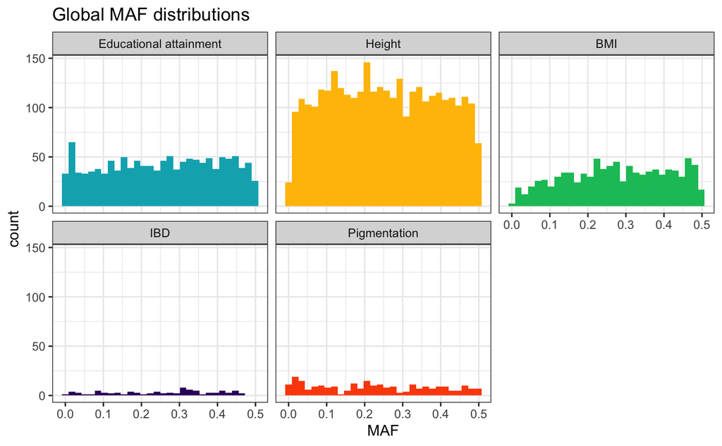

```r
alfreq_glob_df %>%
  ggplot(aes(MAF, fill = trait)) +
    geom_histogram() +
    scale_fill_manual(values = fill_pal) +
    facet_wrap(~trait, nrow = 2) +
    guides(fill = F) +
    theme_bw() +
    ggtitle("Global MAF distributions")
```

```r
# Save
ggsave(here("plots", "20210114_global_maf_distributions.svg"),
       device = "svg",
       units = "cm",
       dpi = 400,
       height = 12,
       width = 19.5)
```